# Most harmful weather events for population health and the economy in the United States between 1950 and 2011

13-5-2020

# Synopsis

Storms and other severe weather events can cause both public health and economic problems for communities and municipalities. This project involves exploring the U.S. National Oceanic and Atmospheric Administration’s (NOAA) storm database. This database tracks characteristics of major storms and weather events in the United States, including estimates of any fatalities, injuries, property damage and crop damage.

This analysis shows that tornado’s cause both the most fatalities and injuries (n=5633 and n=91346). Furthermore, floods are responsible for the most property damage while drought causes the most crop damage. Taken those two together, floods cause the most economic damage (n=150319678257 ).

# Data Processing

The U.S. National Oceanic and Atmospheric Administration’s (NOAA) storm database was downloaded and read in. Only the observations that reported fatalities, injuries, property damage or crop damage were selected. Only the columns that will be used in the analysis were subsetted. This resulted in a dataset that inlcudes 254633 observations of 7 variables.

```r
dataset_url <- "https://d396qusza40orc.cloudfront.net/repdata%2Fdata%2FStormData.csv.bz2"
download.file(dataset_url, "NOAA.csv.bz2")

if (!file.exists("NOAA.csv.bz2")) {
        library(R.utils)
        bunzip2("NOAA.csv.bz2.",
                "NOAA.csv", remove = FALSE) }

NOAA<-read.csv("NOAA.csv")

message(nrow(NOAA), " observations and ", ncol(NOAA), " fields")
```

```
## 902297 observations and 37 fields
```

```r
NOAAsub <- subset(NOAA, FATALITIES > 0 | INJURIES > 0 | PROPDMG > 0 | CROPDMG > 0, select = c(8, 23:28))

nrow(NOAAsub)
```

```
## [1] 254633
```

```r
ncol(NOAAsub)
```

```
## [1] 7
```

1. Across the United States, which types of events (as indicated in the EVTYPE variable) are most harmful with respect to population health? A top 5 of event types is made for both fatalities and injuries.

```r
totFAT <- aggregate(FATALITIES ~ EVTYPE, NOAAsub, FUN = sum, na.rm=TRUE)
totFAT <- totFAT[order(-totFAT$FATALITIES), ]
topFAT <- totFAT[1:5, ]

totINJ <- aggregate(INJURIES ~ EVTYPE, NOAAsub, FUN = sum, na.rm=TRUE)
totINJ <- totINJ[order(-totINJ$INJURIES), ]
topINJ <- totINJ[1:5, ]
```

2.Across the United States, which types of events have the greatest economic consequences? The damage data is seperated in 2 columns: DMG and DMGEXP. The EXP needs to be converted to numeric values and added to the DMG.

```r
expData <- NOAAsub[NOAAsub$PROPDMGEXP %in% c("", "K", "M", "B") & NOAAsub$CROPDMGEXP %in% c("", "K", "M", "B"), ]

convExponent <- function(dmg, exp) {
    if (exp == "K") {
        dmg * 1000
    } else if (exp == "M") {
        dmg * 1e+06
    } else if (exp == "B") {
        dmg * 1e+09
    } else if (exp == "") {
        dmg
    } else {
        stop("NOT VALID DATA")
    }
}

expData$PROP_DMG <- mapply(convExponent, expData$PROPDMG, expData$PROPDMGEXP)
expData$CROP_DMG <- mapply(convExponent, expData$CROPDMG, expData$CROPDMGEXP)
```

A top 5 of event types is made for both crop and property related damage.

```r
totPROP_DMG <- aggregate(PROP_DMG ~ EVTYPE, expData, FUN = sum, na.rm=TRUE)
totPROP_DMG <- totPROP_DMG[order(-totPROP_DMG$PROP_DMG), ]
topPROP_DMG <- totPROP_DMG[1:5, ]

totCROP_DMG <- aggregate(CROP_DMG ~ EVTYPE, expData, FUN = sum, na.rm=TRUE)
totCROP_DMG <- totCROP_DMG[order(-totCROP_DMG$CROP_DMG), ]
topCROP_DMG <- totCROP_DMG[1:5, ]

economicDamage <- aggregate(expData$CROP_DMG + expData$PROP_DMG ~
    EVTYPE, data = expData, sum, na.rm = TRUE)
names(economicDamage) <- c("EVTYPE", "TOTAL_DMG")
economicDamage <- economicDamage[order(-economicDamage$TOTAL_DMG), ]
topTOT_DMG <- economicDamage[1:5, ]
```

# Results

## Population Health related damage

1. Across the United States, which types of events (as indicated in the EVTYPE variable) are most harmful with respect to population health?

```r
print(topFAT)
```

```
##             EVTYPE FATALITIES
## 407        TORNADO       5633
## 61  EXCESSIVE HEAT       1903
## 73     FLASH FLOOD        978
## 151           HEAT        937
## 258      LIGHTNING        816
```

```r
print(topINJ)
```

```
##             EVTYPE INJURIES
## 407        TORNADO    91346
## 423      TSTM WIND     6957
## 86           FLOOD     6789
## 61  EXCESSIVE HEAT     6525
## 258      LIGHTNING     5230
```

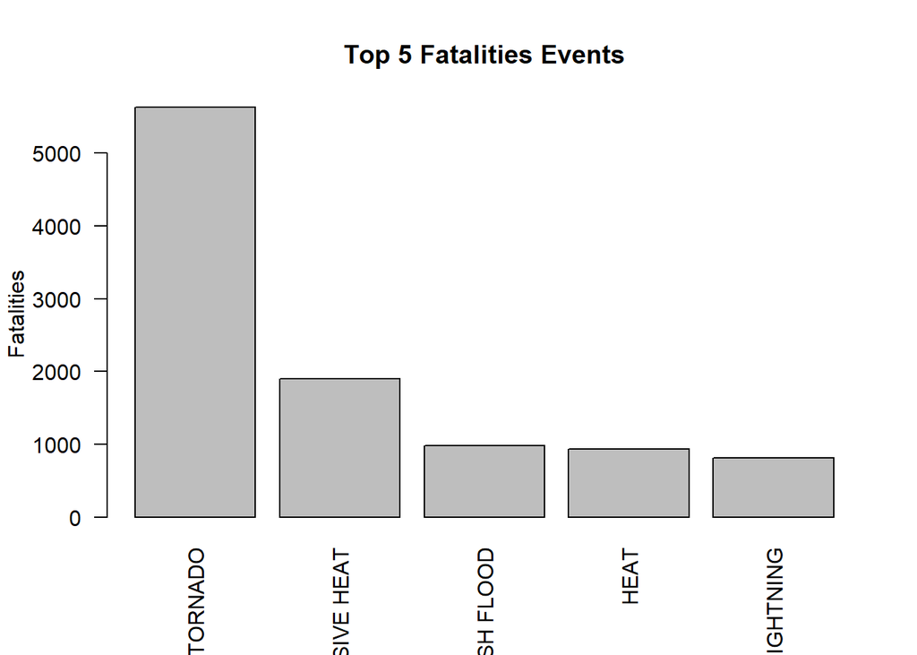

```r
barplot(height = topFAT$FATALITIES, names.arg = topFAT$EVTYPE, xlab="", ylab ="Fatalities", main = "Top 5 Fatalities Events", las=2)
```

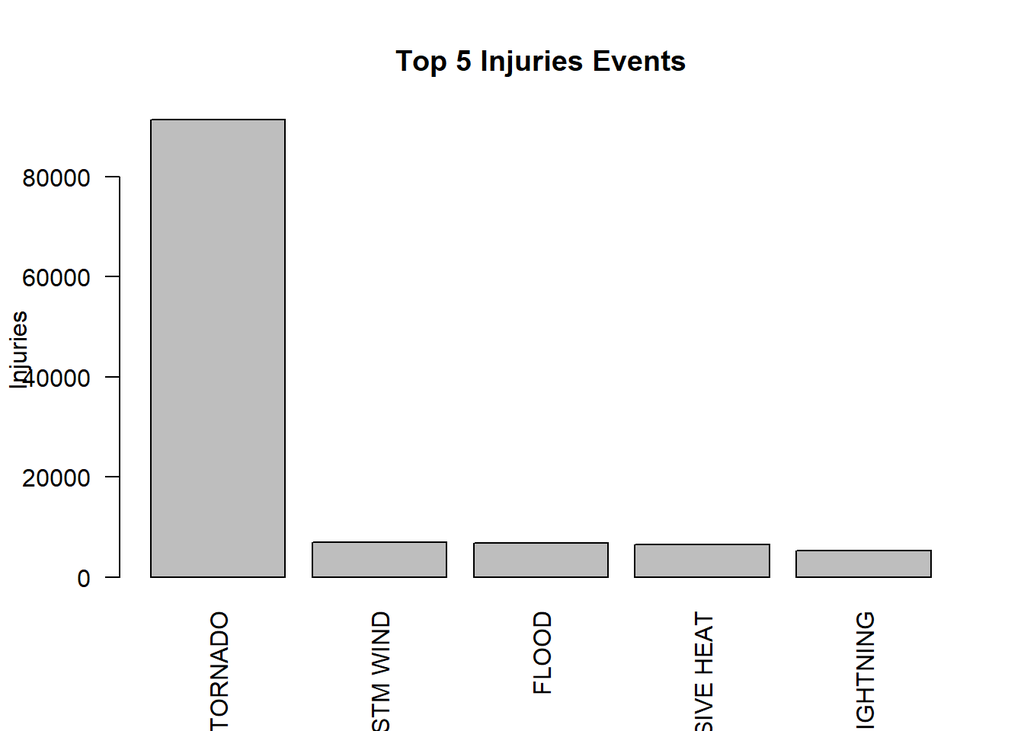

```r
barplot(height = topINJ$INJURIES, names.arg = topINJ$EVTYPE, xlab="", ylab ="Injuries", main = "Top 5 Injuries Events", las=2)
```

## Economic damage

2.Across the United States, which types of events have the greatest economic consequences? As seen in the tables, floods are responsible for the most property damage while drought causes the most crop damage. Taken together, floods cause the most economic damage (n=150319678257 ), as also seen in the figure.

```r
print(topPROP_DMG)
```

```
##                EVTYPE     PROP_DMG
## 84              FLOOD 144657709807
## 219 HURRICANE/TYPHOON  69305840000
## 401           TORNADO  56925485483
## 345       STORM SURGE  43323536000
## 72        FLASH FLOOD  16140811717
```

```r
print(topCROP_DMG)
```

```
##          EVTYPE    CROP_DMG
## 48      DROUGHT 13972566000
## 84        FLOOD  5661968450
## 305 RIVER FLOOD  5029459000
## 233   ICE STORM  5022110000
## 131        HAIL  3000537453
```

```r
print(topTOT_DMG)
```

```
##                EVTYPE    TOTAL_DMG
## 84              FLOOD 150319678257
## 219 HURRICANE/TYPHOON  71913712800
## 401           TORNADO  57290435593
## 345       STORM SURGE  43323541000
## 131              HAIL  18727703230
```

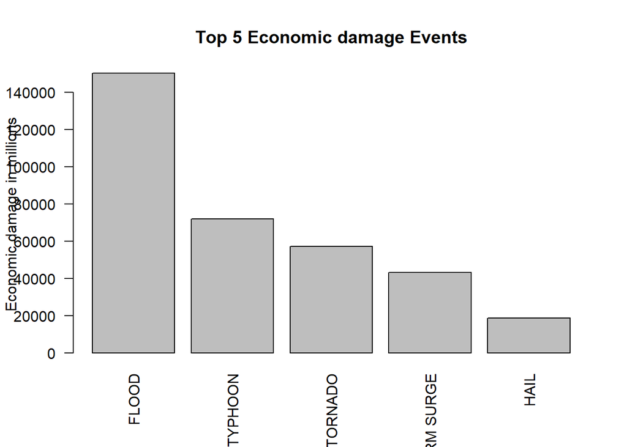

```r
barplot(height = topTOT_DMG$TOTAL_DMG/10^6, names.arg = topTOT_DMG$EVTYPE, xlab="", ylab ="Economic damage in millions", main = "Top 5 Economic damage Events", las=2)
```